# Ford Gobike Exploratory data analysis from year 2017-2019

## Introduction

This data set contains the trip data of Gobike from year 2017 till 2019. The data set contains attributes such as start station, end station, trip duration, user type, gender, etc. We have the data for the past 2 years for this product to analyse its performance and what steps can be taken to improve it by understanding the demographics of the user base.

```python
import pandas as pd
import numpy as np
import seaborn as sb
import matplotlib.pyplot as plt
sb.set(color_codes=True)
%matplotlib inline
```

```python
#reading the data from the csv file
#The data has been cleaned by me earlier in separate notebooks and saved in a master file
df = pd.read_csv('gobike_master_data.csv')
```

```python
df
```

|  | duration_sec | start_time | end_time | start_station_id | start_station_name | end_station_id | end_station_name | bike_id | user_type | member_birth_year | member_gender | bike_share_for_all_trip | day_of_week |
| --- | --- | --- | --- | --- | --- | --- | --- | --- | --- | --- | --- | --- | --- |
| 0 | 80110 | 2017-12-31 16:57:39.654 | 2018-01-01 15:12:50.245 | 74 | Laguna St at Hayes St | 43 | San Francisco Public Library (Grove St at Hyde... | 96 | Customer | 1987 | Male | NaN | 6 |
| 1 | 78800 | 2017-12-31 15:56:34.842 | 2018-01-01 13:49:55.617 | 284 | Yerba Buena Center for the Arts (Howard St at ... | 96 | Dolores St at 15th St | 88 | Customer | 1965 | Female | NaN | 6 |
| 2 | 45768 | 2017-12-31 22:45:48.411 | 2018-01-01 11:28:36.883 | 245 | Downtown Berkeley BART | 245 | Downtown Berkeley BART | 1094 | Customer | 1983 | NaN | NaN | 6 |
| 3 | 62172 | 2017-12-31 17:31:10.636 | 2018-01-01 10:47:23.531 | 60 | 8th St at Ringold St | 5 | Powell St BART Station (Market St at 5th St) | 2831 | Customer | 1983 | NaN | NaN | 6 |
| 4 | 43603 | 2017-12-31 14:23:14.001 | 2018-01-01 02:29:57.571 | 239 | Bancroft Way at Telegraph Ave | 247 | Fulton St at Bancroft Way | 3167 | Subscriber | 1997 | Female | NaN | 6 |
| 5 | 9226 | 2017-12-31 22:51:00.918 | 2018-01-01 01:24:47.166 | 30 | San Francisco Caltrain (Townsend St at 4th St) | 30 | San Francisco Caltrain (Townsend St at 4th St) | 1487 | Customer | 1983 | NaN | NaN | 6 |
| 6 | 4507 | 2017-12-31 23:49:28.422 | 2018-01-01 01:04:35.619 | 259 | Addison St at Fourth St | 259 | Addison St at Fourth St | 3539 | Customer | 1991 | Female | NaN | 6 |
| 7 | 4334 | 2017-12-31 23:46:37.196 | 2018-01-01 00:58:51.211 | 284 | Yerba Buena Center for the Arts (Howard St at ... | 284 | Yerba Buena Center for the Arts (Howard St at ... | 1503 | Customer | 1983 | NaN | NaN | 6 |
| 8 | 4150 | 2017-12-31 23:37:07.548 | 2018-01-01 00:46:18.308 | 20 | Mechanics Monument Plaza (Market St at Bush St) | 20 | Mechanics Monument Plaza (Market St at Bush St) | 3125 | Customer | 1983 | NaN | NaN | 6 |
| 9 | 4238 | 2017-12-31 23:35:38.145 | 2018-01-01 00:46:17.053 | 20 | Mechanics Monument Plaza (Market St at Bush St) | 20 | Mechanics Monument Plaza (Market St at Bush St) | 2543 | Customer | 1983 | NaN | NaN | 6 |
| 10 | 3292 | 2017-12-31 23:46:32.403 | 2018-01-01 00:41:24.605 | 284 | Yerba Buena Center for the Arts (Howard St at ... | 22 | Howard St at Beale St | 3058 | Customer | 1983 | NaN | NaN | 6 |
| 11 | 3177 | 2017-12-31 23:48:11.757 | 2018-01-01 00:41:09.581 | 284 | Yerba Buena Center for the Arts (Howard St at ... | 22 | Howard St at Beale St | 3197 | Customer | 1983 | NaN | NaN | 6 |
| 12 | 2183 | 2017-12-31 23:52:55.581 | 2018-01-01 00:29:18.743 | 67 | San Francisco Caltrain Station 2 (Townsend St... | 24 | Spear St at Folsom St | 2311 | Subscriber | 1990 | Male | NaN | 6 |
| 13 | 2170 | 2017-12-31 23:52:55.937 | 2018-01-01 00:29:06.924 | 67 | San Francisco Caltrain Station 2 (Townsend St... | 24 | Spear St at Folsom St | 3717 | Subscriber | 1990 | Male | NaN | 6 |
| 14 | 2697 | 2017-12-31 23:35:23.222 | 2018-01-01 00:20:20.813 | 66 | 3rd St at Townsend St | 23 | The Embarcadero at Steuart St | 3452 | Customer | 1983 | NaN | NaN | 6 |
| 15 | 1544 | 2017-12-31 23:53:38.943 | 2018-01-01 00:19:23.047 | 14 | Clay St at Battery St | 27 | Beale St at Harrison St | 558 | Subscriber | 1980 | Female | NaN | 6 |
| 16 | 1474 | 2017-12-31 23:54:40.146 | 2018-01-01 00:19:14.351 | 14 | Clay St at Battery St | 27 | Beale St at Harrison St | 3646 | Subscriber | 1979 | Male | NaN | 6 |
| 17 | 1397 | 2017-12-31 23:55:09.686 | 2018-01-01 00:18:26.721 | 78 | Folsom St at 9th St | 15 | San Francisco Ferry Building (Harry Bridges Pl... | 1667 | Customer | 1983 | NaN | NaN | 6 |
| 18 | 1532 | 2017-12-31 23:52:49.497 | 2018-01-01 00:18:21.953 | 78 | Folsom St at 9th St | 15 | San Francisco Ferry Building (Harry Bridges Pl... | 3114 | Subscriber | 1988 | Other | NaN | 6 |
| 19 | 1216 | 2017-12-31 23:46:33.993 | 2018-01-01 00:06:50.058 | 4 | Cyril Magnin St at Ellis St | 123 | Folsom St at 19th St | 1473 | Subscriber | 1971 | Male | NaN | 6 |
| 20 | 386 | 2017-12-31 23:59:01.261 | 2018-01-01 00:05:27.809 | 317 | San Salvador St at 9th St | 296 | 5th St at Virginia St | 1603 | Subscriber | 1992 | Male | NaN | 6 |
| 21 | 4174 | 2017-12-31 22:52:22.286 | 2018-01-01 00:01:56.614 | 30 | San Francisco Caltrain (Townsend St at 4th St) | 6 | The Embarcadero at Sansome St | 809 | Customer | 1983 | NaN | NaN | 6 |
| 22 | 422 | 2017-12-31 23:54:25.337 | 2018-01-01 00:01:27.354 | 139 | Garfield Square (25th St at Harrison St) | 99 | Folsom St at 15th St | 2415 | Subscriber | 1985 | Male | NaN | 6 |
| 23 | 1165 | 2017-12-31 23:35:55.543 | 2017-12-31 23:55:21.220 | 66 | 3rd St at Townsend St | 23 | The Embarcadero at Steuart St | 3671 | Customer | 1983 | NaN | NaN | 6 |
| 24 | 1149 | 2017-12-31 23:36:03.555 | 2017-12-31 23:55:13.465 | 66 | 3rd St at Townsend St | 23 | The Embarcadero at Steuart St | 3375 | Customer | 1983 | NaN | NaN | 6 |
| 25 | 1130 | 2017-12-31 23:36:16.069 | 2017-12-31 23:55:06.096 | 66 | 3rd St at Townsend St | 23 | The Embarcadero at Steuart St | 2721 | Customer | 1983 | NaN | NaN | 6 |
| 26 | 1003 | 2017-12-31 23:36:34.548 | 2017-12-31 23:53:18.195 | 66 | 3rd St at Townsend St | 23 | The Embarcadero at Steuart St | 2522 | Customer | 1983 | NaN | NaN | 6 |
| 27 | 862 | 2017-12-31 23:38:24.874 | 2017-12-31 23:52:47.542 | 6 | The Embarcadero at Sansome St | 15 | San Francisco Ferry Building (Harry Bridges Pl... | 533 | Customer | 1983 | NaN | NaN | 6 |
| 28 | 871 | 2017-12-31 23:37:47.192 | 2017-12-31 23:52:18.473 | 323 | Broadway at Kearny | 14 | Clay St at Battery St | 1456 | Subscriber | 1979 | Male | NaN | 6 |
| 29 | 784 | 2017-12-31 23:39:13.084 | 2017-12-31 23:52:17.293 | 6 | The Embarcadero at Sansome St | 15 | San Francisco Ferry Building (Harry Bridges Pl... | 1691 | Customer | 1983 | NaN | NaN | 6 |
| ... | ... | ... | ... | ... | ... | ... | ... | ... | ... | ... | ... | ... | ... |
| 4554775 | 1081 | 2019-10-01 00:56:20.249 | 2019-10-01 01:14:22.114 | 276 | Julian St at The Alameda | 208 | 4th St at San Carlos St | 12838 | Subscriber | 1995 | Male | Yes | 1 |
| 4554776 | 486 | 2019-10-01 01:04:33.489 | 2019-10-01 01:12:39.748 | 98 | Valencia St at 16th St | 134 | Valencia St at 24th St | 10260 | Customer | 1983 | NaN | No | 1 |
| 4554777 | 216 | 2019-10-01 01:08:17.819 | 2019-10-01 01:11:54.555 | 105 | 16th St at Prosper St | 86 | Market St at Dolores St | 1619 | Subscriber | 1971 | Male | No | 1 |
| 4554778 | 431 | 2019-10-01 01:04:21.601 | 2019-10-01 01:11:33.532 | 98 | Valencia St at 16th St | 134 | Valencia St at 24th St | 12436 | Customer | 1983 | NaN | No | 1 |
| 4554779 | 934 | 2019-10-01 00:55:06.569 | 2019-10-01 01:10:41.313 | 183 | Telegraph Ave at 19th St | 218 | DeFremery Park | 114 | Customer | 1983 | NaN | No | 1 |
| 4554780 | 297 | 2019-10-01 01:00:26.799 | 2019-10-01 01:05:24.412 | 370 | Jones St at Post St | 62 | Victoria Manalo Draves Park | 12197 | Subscriber | 1988 | Male | No | 1 |
| 4554781 | 506 | 2019-10-01 00:46:48.176 | 2019-10-01 00:55:14.518 | 240 | Haste St at Telegraph Ave | 242 | Milvia St at Derby St | 2831 | Subscriber | 1996 | Male | No | 1 |
| 4554782 | 491 | 2019-10-01 00:45:54.685 | 2019-10-01 00:54:06.220 | 122 | 19th St at Mission St | 61 | Howard St at 8th St | 9658 | Subscriber | 1984 | Male | No | 1 |
| 4554783 | 477 | 2019-10-01 00:37:28.542 | 2019-10-01 00:45:25.775 | 240 | Haste St at Telegraph Ave | 240 | Haste St at Telegraph Ave | 3544 | Subscriber | 1997 | Male | No | 1 |
| 4554784 | 776 | 2019-10-01 00:31:45.243 | 2019-10-01 00:44:42.220 | 119 | 18th St at Noe St | 350 | 8th St at Brannan St | 2370 | Subscriber | 1993 | Male | No | 1 |
| 4554785 | 1046 | 2019-10-01 00:20:21.319 | 2019-10-01 00:37:47.972 | 22 | Howard St at Beale St | 64 | 5th St at Brannan St | 9839 | Subscriber | 1997 | Female | No | 1 |
| 4554786 | 822 | 2019-10-01 00:22:47.681 | 2019-10-01 00:36:30.616 | 22 | Howard St at Beale St | 62 | Victoria Manalo Draves Park | 9939 | Subscriber | 1998 | Male | No | 1 |
| 4554787 | 964 | 2019-10-01 00:14:48.693 | 2019-10-01 00:30:52.820 | 167 | College Ave at Harwood Ave | 241 | Ashby BART Station | 1682 | Subscriber | 1976 | Male | No | 1 |
| 4554788 | 575 | 2019-10-01 00:19:13.514 | 2019-10-01 00:28:48.645 | 341 | Fountain Alley at S 2nd St | 278 | The Alameda at Bush St | 1525 | Customer | 1983 | NaN | No | 1 |
| 4554789 | 491 | 2019-10-01 00:19:08.219 | 2019-10-01 00:27:20.145 | 33 | Golden Gate Ave at Hyde St | 58 | Market St at 10th St | 3493 | Customer | 1983 | NaN | No | 1 |
| 4554790 | 1249 | 2019-10-01 00:00:10.892 | 2019-10-01 00:21:00.233 | 109 | 17th St at Valencia St | 460 | Terry Francois Blvd at Warriors Way | 2605 | Customer | 1983 | NaN | No | 1 |
| 4554791 | 372 | 2019-10-01 00:10:55.342 | 2019-10-01 00:17:08.099 | 245 | Downtown Berkeley BART | 254 | Vine St at Shattuck Ave | 12221 | Subscriber | 1988 | Male | No | 1 |
| 4554792 | 634 | 2019-10-01 00:05:22.654 | 2019-10-01 00:15:57.508 | 284 | Yerba Buena Center for the Arts (Howard St at ... | 28 | The Embarcadero at Bryant St | 734 | Subscriber | 1969 | Female | No | 1 |
| 4554793 | 646 | 2019-10-01 00:05:06.675 | 2019-10-01 00:15:53.551 | 284 | Yerba Buena Center for the Arts (Howard St at ... | 28 | The Embarcadero at Bryant St | 10331 | Subscriber | 1963 | Male | No | 1 |
| 4554794 | 131 | 2019-10-01 00:13:19.963 | 2019-10-01 00:15:31.059 | 44 | Civic Center/UN Plaza BART Station (Market St ... | 446 | Mint St at Mission St | 12050 | Subscriber | 1993 | Male | No | 1 |
| 4554795 | 576 | 2019-10-01 00:05:13.518 | 2019-10-01 00:14:49.562 | 98 | Valencia St at 16th St | 109 | 17th St at Valencia St | 12453 | Subscriber | 1980 | Male | No | 1 |
| 4554796 | 834 | 2019-10-01 00:00:14.282 | 2019-10-01 00:14:09.132 | 113 | Franklin Square | 49 | S Park St at 3rd St | 12209 | Subscriber | 1973 | Male | No | 1 |
| 4554797 | 214 | 2019-10-01 00:07:59.010 | 2019-10-01 00:11:33.374 | 121 | Mission Playground | 134 | Valencia St at 24th St | 10205 | Customer | 1983 | NaN | No | 1 |
| 4554798 | 146 | 2019-10-01 00:08:58.156 | 2019-10-01 00:11:24.484 | 258 | University Ave at Oxford St | 238 | MLK Jr Way at University Ave | 37 | Subscriber | 1999 | Male | Yes | 1 |
| 4554799 | 284 | 2019-10-01 00:05:32.659 | 2019-10-01 00:10:16.680 | 89 | Division St at Potrero Ave | 64 | 5th St at Brannan St | 2454 | Subscriber | 1989 | Male | No | 1 |
| 4554800 | 370 | 2019-10-01 00:03:29.945 | 2019-10-01 00:09:40.405 | 177 | MacArthur Blvd at Telegraph Ave | 214 | Market St at Brockhurst St | 2520 | Customer | 1983 | NaN | No | 1 |
| 4554801 | 258 | 2019-10-01 00:04:58.328 | 2019-10-01 00:09:16.509 | 30 | San Francisco Caltrain (Townsend St at 4th St) | 62 | Victoria Manalo Draves Park | 11115 | Subscriber | 1994 | Male | No | 1 |
| 4554802 | 270 | 2019-10-01 00:04:26.234 | 2019-10-01 00:08:57.066 | 129 | Harrison St at 20th St | 336 | Potrero Ave and Mariposa St | 10145 | Subscriber | 1993 | Male | No | 1 |
| 4554803 | 172 | 2019-10-01 00:04:33.492 | 2019-10-01 00:07:25.971 | 211 | Broadway at 40th St | 176 | MacArthur BART Station | 12686 | Subscriber | 1992 | Male | No | 1 |
| 4554804 | 318 | 2019-10-01 00:00:04.964 | 2019-10-01 00:05:22.979 | 21 | Montgomery St BART Station (Market St at 2nd St) | 446 | Mint St at Mission St | 9617 | Subscriber | 1993 | Male | No | 1 |

4554805 rows × 13 columns

```python
df.info()
```

```
<class 'pandas.core.frame.DataFrame'>
RangeIndex: 4554805 entries, 0 to 4554804
Data columns (total 13 columns):
duration_sec               int64
start_time                 object
end_time                   object
start_station_id           int64
start_station_name         object
end_station_id             int64
end_station_name           object
bike_id                    int64
user_type                  object
member_birth_year          int64
member_gender              object
bike_share_for_all_trip    object
day_of_week                int64
dtypes: int64(6), object(7)
memory usage: 451.8+ MB
```

```python
#creating a copy of the data frame to retain original data
df_clean=df.copy()
```

- Converting required data fields to Category type for easier analysis

```python
#Converting attributes to category type and time attributes to datetime for easier manipulation
df_clean['user_type'] = df_clean.user_type.astype('category')
df_clean['member_gender'] = df_clean.member_gender.astype('category')
df_clean['start_time'] = pd.to_datetime(df_clean['start_time'])
df_clean['end_time'] = pd.to_datetime(df_clean['end_time'])
day_order = [0,1,2,3,4,5,6]
df_clean['day_of_week'] = df_clean.day_of_week.astype('category', ordered=True, categories = day_order)
```

```python
df_clean.info()
```

```
<class 'pandas.core.frame.DataFrame'>
RangeIndex: 4554805 entries, 0 to 4554804
Data columns (total 13 columns):
duration_sec               int64
start_time                 datetime64[ns]
end_time                   datetime64[ns]
start_station_id           int64
start_station_name         object
end_station_id             int64
end_station_name           object
bike_id                    int64
user_type                  category
member_birth_year          int64
member_gender              category
bike_share_for_all_trip    object
day_of_week                category
dtypes: category(3), datetime64[ns](2), int64(5), object(3)
memory usage: 360.5+ MB
```

### Consumer comparison(Univariate)

- Whenever we look at a product such as Gobike we need to understand what and how many users are using it. In this data set we have subscribers and customers, which can be further segregated into their genders. First let's find out which group of user type has a higher count?

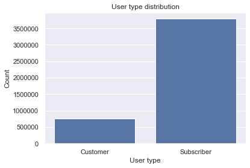

```python
base_color = sb.color_palette()[0]
sb.countplot(data=df_clean, x='user_type',color=base_color);
plt.xlabel('User type');
plt.ylabel('Count');
plt.title('User type distribution');
```

```python
#to find out the percentage of the subscribers and the customers
dist = []
dist.append(df_clean.user_type.value_counts()[0]/(df_clean.user_type.value_counts()[0]+df_clean.user_type.value_counts())[1]*100)
dist.append(df_clean.user_type.value_counts()[1]/(df_clean.user_type.value_counts()[0]+df_clean.user_type.value_counts()[1])*100)
dist
```

```
[16.746117561564105, 83.2538824384359]
```

- I have created a count plot to compare the number of different user types which is a Univariate plot ,i.e., only one variable is being used. We can see that the subscribers are 83% while the customers are at approximately 17%. This graph could also be plotted in the form of a pie chart which is also a good way to plot a univariate analysis.

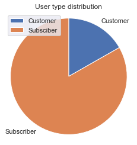

```python
dist = []
dist.append(df_clean.user_type.value_counts()[0]/(df_clean.user_type.value_counts()[0]+df_clean.user_type.value_counts())[1]*100)
dist.append(df_clean.user_type.value_counts()[1]/(df_clean.user_type.value_counts()[0]+df_clean.user_type.value_counts()[1])*100)
df_clean.user_type.unique()
labels = ['Customer', 'Subsciber']
patches, texts = plt.pie(dist, labels = df_clean.user_type.unique(), startangle = 90, counterclock = False);
plt.axis('square');
plt.legend(patches, labels, loc="best");
plt.title('User type distribution');
```

- To better understand the demographics we need to segregate this data further. What is the distributon of the males, females and other genders?

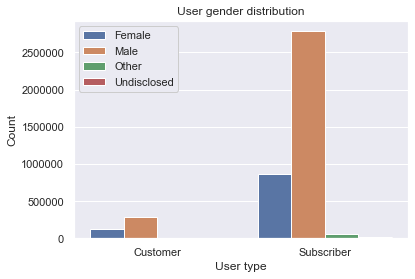

```python
#segregating the subscribers by their genders(bivariate)
#countplot between subscibers and customers
ax = sb.countplot(data = df_clean, x = 'user_type', hue = 'member_gender');
ax.legend(loc = 2, framealpha = 1); # upper left, no transparency
plt.xlabel('User type');
plt.ylabel('Count');
plt.title('User gender distribution');
```

### Comparing the trip duration of different user types(bivariate analysis)

- After looking at the distribution of the user types, we should also know the trip duration these two categories usually book?

```python
#to find out the mean trip durations of the user types
cdur = df_clean.query('user_type == "Customer"').duration_sec.mean()
sdur = df_clean.query('user_type == "Subscriber"').duration_sec.mean()
cdur, sdur
```

```
(1787.5890425865255, 675.7974827349414)
```

- We see here that the mean trip duration of the customer is more than twice of what it is of the subscribers.This does not feel right. For this I will plot a box plot to compare the means between the two user types and also to understand the outliers in the data set.

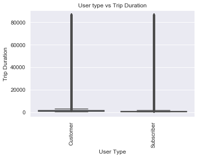

```python
#boxplot between user_type and duration_sec
sb.boxplot(data=df_clean, x='user_type', y='duration_sec', color=base_color);
plt.xticks(rotation=90);
plt.xlabel('User Type');
plt.ylabel('Trip Duration');
plt.title('User type vs Trip Duration');
```

- We can see above that the outlier values are much larger than the general data distribution and hence we are not able to get a clearer idea of the data distribution. So, I need to filter out the dution_sec data with much lower value to understand the same

```python
#taking out the trip duration which is less than 4000 secs to get a more better graph
bike_div = df_clean.query('duration_sec < 4000')
```

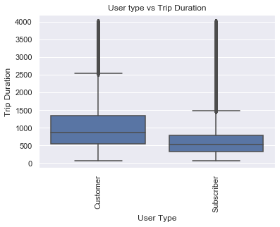

```python
#boxplot between user_type and duration_sec with duration sec less than 4000
sb.boxplot(data=bike_div, x='user_type', y='duration_sec', color=base_color);
plt.xticks(rotation=90);
plt.xlabel('User Type');
plt.ylabel('Trip Duration');
plt.title('User type vs Trip Duration');
```

- We can clearly see here that the mean usage time of the Customer is more than the subscriber, but not as much as we saw in the data computation by just calculating the mean. Therefore, sometimes a visual representation of the data provides us with a much better idea about the same. The one thing that we can understand from this is that the current customers should be converted to subscribers for better product statistics and value.

### Trip duration comparision between different genders of the suer types (multivariate analysis)

- Since we know that the trip duration for the customers is more than that of the subscribers and we also know that the the number of male users are much more than any of the other genders, is it safe to assume that the trip duration of the male members is also more than the other genders? I will plot a barplot between the mean trip duration between the genders in different user types which is a type of Multivariate analysis

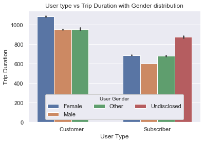

```python
ax = sb.barplot(data = bike_div, x = 'user_type', y = 'duration_sec', hue='member_gender')
ax.legend(loc = 8, ncol = 3, framealpha = 1, title = 'User Gender')
plt.xlabel('User Type');
plt.ylabel('Trip Duration');
plt.title('User type vs Trip Duration with Gender distribution');
```

- In the above graph we see that even though the number of trips by males is more, the trip duration is lower than other gender groups. This was kind of a paradox and a misconeption many would have made if they do not see this visualisation. So despite the fact that more number of males are using the gobike, their mean trip duration is the lowest when you compare with the trip duration of other genders. This means that if a drive to focus to get other gender groups is initiated it would result in more revenue generation and also diversifies the product a bit more.

### Trips comparison between days of the week (Univariate analysis)

- One importnt thing to note is the trend of the trips being booked over the week. For this I will be plotting a graph of the trips over the different days of the week to understand this trend. I will use a facet grid plot to see this trend. Since the two main gender groups in this case are male and female, I will be using only these two gender groups for this analysis.

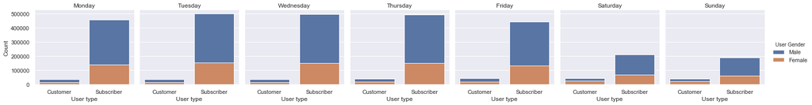

```python
df_div = df_clean.query('member_gender == "Male" or member_gender == "Female"')
g = sb.FacetGrid(data = df_div, col = 'day_of_week', hue = 'member_gender', hue_order = ['Male','Female'], size=3);
g.map(sb.countplot, 'user_type').add_legend(title = 'User Gender');
g.set_titles('{col_name}');
g.set_axis_labels('User type','Count');
g.set_titles('User type with Day of week distribution');
ax = g.axes.flatten();
ax[0].set_title('Monday');
ax[1].set_title('Tuesday');
ax[2].set_title('Wednesday');
ax[3].set_title('Thursday');
ax[4].set_title('Friday');
ax[5].set_title('Saturday');
ax[6].set_title('Sunday');
```

### Trip duration trend over time with bike share (bivariate analysis)

- What is the trip duration trend over time? Is the trip duration over time increasing or decreasing? We need to understand this aspect of the data as well to get an idea how well the user are engaged with Gobike. If there is a decreasing trip duration it may also eventually mean that people are losing interest or less revenue generated from the product.

```python
#taking the data where the gender is either male or female
df_mf = df_clean.query('member_gender == "Female" or member_gender == "Male"')
df_mf
```

|  | duration_sec | start_time | end_time | start_station_id | start_station_name | end_station_id | end_station_name | bike_id | user_type | member_birth_year | member_gender | bike_share_for_all_trip | day_of_week |
| --- | --- | --- | --- | --- | --- | --- | --- | --- | --- | --- | --- | --- | --- |
| 0 | 80110 | 2017-12-31 16:57:39.654 | 2018-01-01 15:12:50.245 | 74 | Laguna St at Hayes St | 43 | San Francisco Public Library (Grove St at Hyde... | 96 | Customer | 1987 | Male | NaN | 6 |
| 1 | 78800 | 2017-12-31 15:56:34.842 | 2018-01-01 13:49:55.617 | 284 | Yerba Buena Center for the Arts (Howard St at ... | 96 | Dolores St at 15th St | 88 | Customer | 1965 | Female | NaN | 6 |
| 4 | 43603 | 2017-12-31 14:23:14.001 | 2018-01-01 02:29:57.571 | 239 | Bancroft Way at Telegraph Ave | 247 | Fulton St at Bancroft Way | 3167 | Subscriber | 1997 | Female | NaN | 6 |
| 6 | 4507 | 2017-12-31 23:49:28.422 | 2018-01-01 01:04:35.619 | 259 | Addison St at Fourth St | 259 | Addison St at Fourth St | 3539 | Customer | 1991 | Female | NaN | 6 |
| 12 | 2183 | 2017-12-31 23:52:55.581 | 2018-01-01 00:29:18.743 | 67 | San Francisco Caltrain Station 2 (Townsend St... | 24 | Spear St at Folsom St | 2311 | Subscriber | 1990 | Male | NaN | 6 |
| 13 | 2170 | 2017-12-31 23:52:55.937 | 2018-01-01 00:29:06.924 | 67 | San Francisco Caltrain Station 2 (Townsend St... | 24 | Spear St at Folsom St | 3717 | Subscriber | 1990 | Male | NaN | 6 |
| 15 | 1544 | 2017-12-31 23:53:38.943 | 2018-01-01 00:19:23.047 | 14 | Clay St at Battery St | 27 | Beale St at Harrison St | 558 | Subscriber | 1980 | Female | NaN | 6 |
| 16 | 1474 | 2017-12-31 23:54:40.146 | 2018-01-01 00:19:14.351 | 14 | Clay St at Battery St | 27 | Beale St at Harrison St | 3646 | Subscriber | 1979 | Male | NaN | 6 |
| 19 | 1216 | 2017-12-31 23:46:33.993 | 2018-01-01 00:06:50.058 | 4 | Cyril Magnin St at Ellis St | 123 | Folsom St at 19th St | 1473 | Subscriber | 1971 | Male | NaN | 6 |
| 20 | 386 | 2017-12-31 23:59:01.261 | 2018-01-01 00:05:27.809 | 317 | San Salvador St at 9th St | 296 | 5th St at Virginia St | 1603 | Subscriber | 1992 | Male | NaN | 6 |
| 22 | 422 | 2017-12-31 23:54:25.337 | 2018-01-01 00:01:27.354 | 139 | Garfield Square (25th St at Harrison St) | 99 | Folsom St at 15th St | 2415 | Subscriber | 1985 | Male | NaN | 6 |
| 28 | 871 | 2017-12-31 23:37:47.192 | 2017-12-31 23:52:18.473 | 323 | Broadway at Kearny | 14 | Clay St at Battery St | 1456 | Subscriber | 1979 | Male | NaN | 6 |
| 32 | 733 | 2017-12-31 23:38:38.861 | 2017-12-31 23:50:52.504 | 323 | Broadway at Kearny | 14 | Clay St at Battery St | 1634 | Subscriber | 1980 | Female | NaN | 6 |
| 33 | 781 | 2017-12-31 23:33:52.981 | 2017-12-31 23:46:54.972 | 251 | California St at University Ave | 259 | Addison St at Fourth St | 3539 | Customer | 1991 | Female | NaN | 6 |
| 34 | 475 | 2017-12-31 23:37:35.545 | 2017-12-31 23:45:30.808 | 7 | Frank H Ogawa Plaza | 230 | 14th St at Mandela Pkwy | 3598 | Subscriber | 1978 | Male | NaN | 6 |
| 35 | 152 | 2017-12-31 23:41:32.917 | 2017-12-31 23:44:05.047 | 96 | Dolores St at 15th St | 86 | Market St at Dolores St | 2728 | Subscriber | 1980 | Male | NaN | 6 |
| 36 | 249 | 2017-12-31 23:38:37.736 | 2017-12-31 23:42:47.211 | 278 | The Alameda at Bush St | 314 | Santa Clara St at Almaden Blvd | 47 | Subscriber | 1993 | Male | NaN | 6 |
| 39 | 243 | 2017-12-31 23:34:46.302 | 2017-12-31 23:38:49.303 | 182 | 19th Street BART Station | 195 | Bay Pl at Vernon St | 2674 | Subscriber | 1977 | Male | NaN | 6 |
| 40 | 833 | 2017-12-31 23:24:48.513 | 2017-12-31 23:38:41.520 | 98 | Valencia St at 16th St | 62 | Victoria Manalo Draves Park | 1227 | Subscriber | 1984 | Male | NaN | 6 |
| 41 | 820 | 2017-12-31 23:24:49.373 | 2017-12-31 23:38:29.829 | 98 | Valencia St at 16th St | 62 | Victoria Manalo Draves Park | 3595 | Subscriber | 1983 | Female | NaN | 6 |
| 46 | 538 | 2017-12-31 23:24:34.580 | 2017-12-31 23:33:33.475 | 85 | Church St at Duboce Ave | 120 | Mission Dolores Park | 1780 | Customer | 1991 | Male | NaN | 6 |
| 47 | 577 | 2017-12-31 23:20:38.013 | 2017-12-31 23:30:15.883 | 124 | 19th St at Florida St | 134 | Valencia St at 24th St | 3067 | Subscriber | 1978 | Male | NaN | 6 |
| 48 | 418 | 2017-12-31 23:22:04.850 | 2017-12-31 23:29:03.008 | 249 | Russell St at College Ave | 172 | College Ave at Taft Ave | 1439 | Subscriber | 1967 | Male | NaN | 6 |
| 52 | 707 | 2017-12-31 23:14:07.542 | 2017-12-31 23:25:55.455 | 245 | Downtown Berkeley BART | 259 | Addison St at Fourth St | 2966 | Customer | 1994 | Male | NaN | 6 |
| 54 | 1240 | 2017-12-31 23:02:58.155 | 2017-12-31 23:23:38.675 | 45 | 5th St at Howard St | 133 | Valencia St at 22nd St | 1159 | Subscriber | 1974 | Male | NaN | 6 |
| 58 | 552 | 2017-12-31 23:03:14.830 | 2017-12-31 23:12:27.188 | 127 | Valencia St at 21st St | 146 | 30th St at San Jose Ave | 3029 | Subscriber | 1968 | Female | NaN | 6 |
| 59 | 546 | 2017-12-31 23:02:56.479 | 2017-12-31 23:12:03.454 | 127 | Valencia St at 21st St | 146 | 30th St at San Jose Ave | 3661 | Subscriber | 1962 | Male | NaN | 6 |
| 60 | 196 | 2017-12-31 23:05:57.725 | 2017-12-31 23:09:13.951 | 132 | 24th St at Chattanooga St | 137 | Jersey St at Castro St | 2407 | Subscriber | 1989 | Male | NaN | 6 |
| 62 | 323 | 2017-12-31 23:00:50.666 | 2017-12-31 23:06:14.426 | 182 | 19th Street BART Station | 159 | 24th St at Market St | 3272 | Subscriber | 1987 | Male | NaN | 6 |
| 63 | 628 | 2017-12-31 22:51:56.844 | 2017-12-31 23:02:25.833 | 27 | Beale St at Harrison St | 66 | 3rd St at Townsend St | 3182 | Subscriber | 1986 | Male | NaN | 6 |
| ... | ... | ... | ... | ... | ... | ... | ... | ... | ... | ... | ... | ... | ... |
| 4554761 | 452 | 2019-10-01 01:41:54.524 | 2019-10-01 01:49:27.301 | 314 | Santa Clara St at Almaden Blvd | 470 | N 14th St at E Santa Clara St | 12975 | Subscriber | 1984 | Male | No | 1 |
| 4554762 | 280 | 2019-10-01 01:44:12.879 | 2019-10-01 01:48:53.002 | 180 | Telegraph Ave at 23rd St | 217 | 27th St at MLK Jr Way | 2442 | Subscriber | 1966 | Male | Yes | 1 |
| 4554763 | 262 | 2019-10-01 01:42:20.212 | 2019-10-01 01:46:42.776 | 133 | Valencia St at 22nd St | 147 | 29th St at Tiffany Ave | 12370 | Subscriber | 1981 | Male | No | 1 |
| 4554764 | 577 | 2019-10-01 01:33:13.143 | 2019-10-01 01:42:50.251 | 305 | Ryland Park | 280 | San Fernando St at 7th St | 11691 | Subscriber | 1994 | Male | Yes | 1 |
| 4554765 | 279 | 2019-10-01 01:35:41.787 | 2019-10-01 01:40:21.554 | 296 | 5th St at Virginia St | 317 | San Salvador St at 9th St | 10413 | Subscriber | 1995 | Male | Yes | 1 |
| 4554770 | 387 | 2019-10-01 01:32:14.226 | 2019-10-01 01:38:41.423 | 16 | Steuart St at Market St | 10 | Washington St at Kearny St | 10402 | Subscriber | 1985 | Female | Yes | 1 |
| 4554772 | 303 | 2019-10-01 01:22:17.840 | 2019-10-01 01:27:20.890 | 75 | Market St at Franklin St | 33 | Golden Gate Ave at Hyde St | 9589 | Subscriber | 1971 | Male | No | 1 |
| 4554773 | 190 | 2019-10-01 01:21:49.410 | 2019-10-01 01:25:00.002 | 196 | Grand Ave at Perkins St | 197 | El Embarcadero at Grand Ave | 10407 | Subscriber | 1979 | Male | No | 1 |
| 4554775 | 1081 | 2019-10-01 00:56:20.249 | 2019-10-01 01:14:22.114 | 276 | Julian St at The Alameda | 208 | 4th St at San Carlos St | 12838 | Subscriber | 1995 | Male | Yes | 1 |
| 4554777 | 216 | 2019-10-01 01:08:17.819 | 2019-10-01 01:11:54.555 | 105 | 16th St at Prosper St | 86 | Market St at Dolores St | 1619 | Subscriber | 1971 | Male | No | 1 |
| 4554780 | 297 | 2019-10-01 01:00:26.799 | 2019-10-01 01:05:24.412 | 370 | Jones St at Post St | 62 | Victoria Manalo Draves Park | 12197 | Subscriber | 1988 | Male | No | 1 |
| 4554781 | 506 | 2019-10-01 00:46:48.176 | 2019-10-01 00:55:14.518 | 240 | Haste St at Telegraph Ave | 242 | Milvia St at Derby St | 2831 | Subscriber | 1996 | Male | No | 1 |
| 4554782 | 491 | 2019-10-01 00:45:54.685 | 2019-10-01 00:54:06.220 | 122 | 19th St at Mission St | 61 | Howard St at 8th St | 9658 | Subscriber | 1984 | Male | No | 1 |
| 4554783 | 477 | 2019-10-01 00:37:28.542 | 2019-10-01 00:45:25.775 | 240 | Haste St at Telegraph Ave | 240 | Haste St at Telegraph Ave | 3544 | Subscriber | 1997 | Male | No | 1 |
| 4554784 | 776 | 2019-10-01 00:31:45.243 | 2019-10-01 00:44:42.220 | 119 | 18th St at Noe St | 350 | 8th St at Brannan St | 2370 | Subscriber | 1993 | Male | No | 1 |
| 4554785 | 1046 | 2019-10-01 00:20:21.319 | 2019-10-01 00:37:47.972 | 22 | Howard St at Beale St | 64 | 5th St at Brannan St | 9839 | Subscriber | 1997 | Female | No | 1 |
| 4554786 | 822 | 2019-10-01 00:22:47.681 | 2019-10-01 00:36:30.616 | 22 | Howard St at Beale St | 62 | Victoria Manalo Draves Park | 9939 | Subscriber | 1998 | Male | No | 1 |
| 4554787 | 964 | 2019-10-01 00:14:48.693 | 2019-10-01 00:30:52.820 | 167 | College Ave at Harwood Ave | 241 | Ashby BART Station | 1682 | Subscriber | 1976 | Male | No | 1 |
| 4554791 | 372 | 2019-10-01 00:10:55.342 | 2019-10-01 00:17:08.099 | 245 | Downtown Berkeley BART | 254 | Vine St at Shattuck Ave | 12221 | Subscriber | 1988 | Male | No | 1 |
| 4554792 | 634 | 2019-10-01 00:05:22.654 | 2019-10-01 00:15:57.508 | 284 | Yerba Buena Center for the Arts (Howard St at ... | 28 | The Embarcadero at Bryant St | 734 | Subscriber | 1969 | Female | No | 1 |
| 4554793 | 646 | 2019-10-01 00:05:06.675 | 2019-10-01 00:15:53.551 | 284 | Yerba Buena Center for the Arts (Howard St at ... | 28 | The Embarcadero at Bryant St | 10331 | Subscriber | 1963 | Male | No | 1 |
| 4554794 | 131 | 2019-10-01 00:13:19.963 | 2019-10-01 00:15:31.059 | 44 | Civic Center/UN Plaza BART Station (Market St ... | 446 | Mint St at Mission St | 12050 | Subscriber | 1993 | Male | No | 1 |
| 4554795 | 576 | 2019-10-01 00:05:13.518 | 2019-10-01 00:14:49.562 | 98 | Valencia St at 16th St | 109 | 17th St at Valencia St | 12453 | Subscriber | 1980 | Male | No | 1 |
| 4554796 | 834 | 2019-10-01 00:00:14.282 | 2019-10-01 00:14:09.132 | 113 | Franklin Square | 49 | S Park St at 3rd St | 12209 | Subscriber | 1973 | Male | No | 1 |
| 4554798 | 146 | 2019-10-01 00:08:58.156 | 2019-10-01 00:11:24.484 | 258 | University Ave at Oxford St | 238 | MLK Jr Way at University Ave | 37 | Subscriber | 1999 | Male | Yes | 1 |
| 4554799 | 284 | 2019-10-01 00:05:32.659 | 2019-10-01 00:10:16.680 | 89 | Division St at Potrero Ave | 64 | 5th St at Brannan St | 2454 | Subscriber | 1989 | Male | No | 1 |
| 4554801 | 258 | 2019-10-01 00:04:58.328 | 2019-10-01 00:09:16.509 | 30 | San Francisco Caltrain (Townsend St at 4th St) | 62 | Victoria Manalo Draves Park | 11115 | Subscriber | 1994 | Male | No | 1 |
| 4554802 | 270 | 2019-10-01 00:04:26.234 | 2019-10-01 00:08:57.066 | 129 | Harrison St at 20th St | 336 | Potrero Ave and Mariposa St | 10145 | Subscriber | 1993 | Male | No | 1 |
| 4554803 | 172 | 2019-10-01 00:04:33.492 | 2019-10-01 00:07:25.971 | 211 | Broadway at 40th St | 176 | MacArthur BART Station | 12686 | Subscriber | 1992 | Male | No | 1 |
| 4554804 | 318 | 2019-10-01 00:00:04.964 | 2019-10-01 00:05:22.979 | 21 | Montgomery St BART Station (Market St at 2nd St) | 446 | Mint St at Mission St | 9617 | Subscriber | 1993 | Male | No | 1 |

4055894 rows × 13 columns

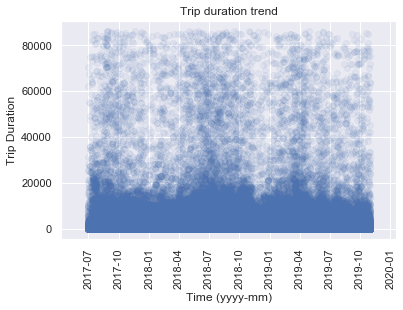

```python
plt.scatter(data=df_mf, x= 'start_time', y = 'duration_sec', alpha = 1/15);
plt.xticks(rotation = 90);
plt.xlabel('Time (yyyy-mm)');
plt.ylabel('Trip Duration');
plt.title('Trip duration trend');
```

## Conclusions

- The major concern like for all data are the outliers which will make the statistics look ambiguous and goofy very much like our case today. It is important to identify them and not consider them in our computations. These finding can be used to further analyse our data to get new insights and create much more elaborate visualisations